# Introduction to Pandas

## Importing data

A key, but often under-appreciated, step in data analysis is importing the data that we wish to analyze. Though it is easy to load basic data structures into Python using built-in tools or those provided by packages like NumPy, it is non-trivial to import structured data well, and to easily convert this input into a robust data structure:

```
genes = np.loadtxt("genes.csv", delimiter=",", dtype=[('gene', '|S10'), ('value', '<f4')])
```

Pandas provides a convenient set of functions for importing tabular data in a number of formats directly into a `DataFrame` object. These functions include a slew of options to perform type inference, indexing, parsing, iterating and cleaning automatically as data are imported.

Let's start with some more bacteria data, stored in csv format.

```python
!head data/microbiome.csv
```

[output not shown]

This table can be read into a DataFrame using `read_csv`:

```python
mb = pd.read_csv("data/microbiome.csv")
mb.head()
```

|  | Taxon | Patient | Tissue | Stool |
| --- | --- | --- | --- | --- |
| 0 | Firmicutes | 1 | 632 | 305 |
| 1 | Firmicutes | 2 | 136 | 4182 |
| 2 | Firmicutes | 3 | 1174 | 703 |
| 3 | Firmicutes | 4 | 408 | 3946 |
| 4 | Firmicutes | 5 | 831 | 8605 |

```python
mb.shape[1]
```

```
4
```

Notice that `read_csv` automatically considered the first row in the file to be a header row.

We can override default behavior by customizing some the arguments, like `header`, `names` or `index_col`.

```python
l.columns = l.loc[0, :]
l.head()
```

[output not shown]

```python
l.drop([0], axis=0)
```

[output not shown]

For a more useful index, we can specify the first two columns, which together provide a unique index to the data.

```python
mb = pd.read_csv("data/microbiome.csv", index_col=['Taxon','Patient'])
mb.head()
```

| Taxon | Patient | Tissue | Stool |
| --- | --- | --- | --- |
| Firmicutes | 1 | 632 | 305 |
|  | 2 | 136 | 4182 |
|  | 3 | 1174 | 703 |
|  | 4 | 408 | 3946 |
|  | 5 | 831 | 8605 |

This is called a *hierarchical* index, which we will revisit later.

```python
import random
```

```python
mb.shape
```

```
(75, 2)
```

```python
mb.head()
```

| Taxon | Patient | Tissue | Stool |
| --- | --- | --- | --- |
| Firmicutes | 1 | 632 | 305 |
|  | 2 | 136 | 4182 |
|  | 3 | 1174 | 703 |
|  | 4 | 408 | 3946 |
|  | 5 | 831 | 8605 |

```python
df.head()
```

[output not shown]

Alternately, if we want to process our data in reasonable chunks, the `chunksize` argument will return an iterable object that can be employed in a data processing loop. For example, our microbiome data are organized by bacterial phylum, with 15 patients represented in each:

```python
l = pd.read_csv("data/microbiome.csv")
l.head()
```

|  | Taxon | Patient | Tissue | Stool |
| --- | --- | --- | --- | --- |
| 0 | Firmicutes | 1 | 632 | 305 |
| 1 | Firmicutes | 2 | 136 | 4182 |
| 2 | Firmicutes | 3 | 1174 | 703 |
| 3 | Firmicutes | 4 | 408 | 3946 |
| 4 | Firmicutes | 5 | 831 | 8605 |

```python
data_chunks = pd.read_csv("data/microbiome.csv", chunksize=15)

mean_tissue = {chunk.Taxon.iloc[2]:chunk.Tissue.mean() for chunk in data_chunks}

mean_tissue
```

```
{'Firmicutes': 684.4,
 'Proteobacteria': 2943.0666666666666,
 'Actinobacteria': 449.06666666666666,
 'Bacteroidetes': 599.6666666666666,
 'Other': 198.8}
```

Most real-world data is incomplete, with values missing due to incomplete observation, data entry or transcription error, or other reasons. Pandas will automatically recognize and parse common missing data indicators, including `NA` and `NULL`.

```python
!head -10 data/microbiome_missing.csv
```

[output not shown]

```python
pd.read_csv("data/microbiome_missing.csv").head(20)
```

|  | Taxon | Patient | Tissue | Stool |
| --- | --- | --- | --- | --- |
| 0 | Firmicutes | 1 | 632 | 305.0 |
| 1 | Firmicutes | 2 | 136 | 4182.0 |
| 2 | Firmicutes | 3 | NaN | 703.0 |
| 3 | Firmicutes | 4 | 408 | 3946.0 |
| 4 | Firmicutes | 5 | 831 | 8605.0 |
| 5 | Firmicutes | 6 | 693 | 50.0 |
| 6 | Firmicutes | 7 | 718 | 717.0 |
| 7 | Firmicutes | 8 | 173 | 33.0 |
| 8 | Firmicutes | 9 | 228 | NaN |
| 9 | Firmicutes | 10 | 162 | 3196.0 |
| 10 | Firmicutes | 11 | 372 | -99999.0 |
| 11 | Firmicutes | 12 | 4255 | 4361.0 |
| 12 | Firmicutes | 13 | 107 | 1667.0 |
| 13 | Firmicutes | 14 | ? | 223.0 |
| 14 | Firmicutes | 15 | 281 | 2377.0 |
| 15 | Proteobacteria | 1 | 1638 | 3886.0 |
| 16 | Proteobacteria | 2 | 2469 | 1821.0 |
| 17 | Proteobacteria | 3 | 839 | 661.0 |
| 18 | Proteobacteria | 4 | 4414 | 18.0 |
| 19 | Proteobacteria | 5 | 12044 | 83.0 |

Above, Pandas recognized `NA` and an empty field as missing data.

```python
pd.isnull(pd.read_csv("data/microbiome_missing.csv")).head(10)
```

|  | Taxon | Patient | Tissue | Stool |
| --- | --- | --- | --- | --- |
| 0 | False | False | False | False |
| 1 | False | False | False | False |
| 2 | False | False | True | False |
| 3 | False | False | False | False |
| 4 | False | False | False | False |
| 5 | False | False | False | False |
| 6 | False | False | False | False |
| 7 | False | False | False | False |
| 8 | False | False | False | True |
| 9 | False | False | False | False |

```python
l.drop_duplicates(inplace = True)
```

```python
pd.api.types.is_sparse(l)
def preprocessing(df):
    cols = df.columns.tolist()
    l = []
    b = []
    for col in cols:
        if pd.api.types.is_sparse(df[col])==True:
            l.append(col)
        if df[col].isnull().sum() >0:
            b.append(col)
    return l==[] and b==[] #or just return l,b

preprocessing(l)
```

```
True
```

```python
l.drop_duplicates()
```

```python
l[l.duplicated()!=True]
```

|  | Taxon | Patient | Tissue | Stool |
| --- | --- | --- | --- | --- |
| 0 | Firmicutes | 1 | 632 | 305 |
| 1 | Firmicutes | 2 | 136 | 4182 |
| 2 | Firmicutes | 3 | 1174 | 703 |
| 3 | Firmicutes | 4 | 408 | 3946 |
| 4 | Firmicutes | 5 | 831 | 8605 |
| ... | ... | ... | ... | ... |
| 70 | Other | 11 | 203 | 6 |
| 71 | Other | 12 | 392 | 6 |
| 72 | Other | 13 | 28 | 25 |
| 73 | Other | 14 | 12 | 22 |
| 74 | Other | 15 | 305 | 32 |

75 rows × 4 columns

```python
l[l.notnull()]
```

|  | Taxon | Patient | Tissue | Stool |
| --- | --- | --- | --- | --- |
| 0 | Firmicutes | 1 | 632 | 305 |
| 1 | Firmicutes | 2 | 136 | 4182 |
| 2 | Firmicutes | 3 | 1174 | 703 |
| 3 | Firmicutes | 4 | 408 | 3946 |
| 4 | Firmicutes | 5 | 831 | 8605 |
| ... | ... | ... | ... | ... |
| 70 | Other | 11 | 203 | 6 |
| 71 | Other | 12 | 392 | 6 |
| 72 | Other | 13 | 28 | 25 |
| 73 | Other | 14 | 12 | 22 |
| 74 | Other | 15 | 305 | 32 |

75 rows × 4 columns

Unfortunately, there will sometimes be inconsistency with the conventions for missing data. In this example, there is a question mark "?" and a large negative number where there should have been a positive integer. We can specify additional symbols with the `na_values` argument:

```python
pd.read_csv("data/microbiome_missing.csv", na_values=['?', -99999]).head(20)
```

|  | Taxon | Patient | Tissue | Stool |
| --- | --- | --- | --- | --- |
| 0 | Firmicutes | 1 | 632.0 | 305.0 |
| 1 | Firmicutes | 2 | 136.0 | 4182.0 |
| 2 | Firmicutes | 3 | NaN | 703.0 |
| 3 | Firmicutes | 4 | 408.0 | 3946.0 |
| 4 | Firmicutes | 5 | 831.0 | 8605.0 |
| 5 | Firmicutes | 6 | 693.0 | 50.0 |
| 6 | Firmicutes | 7 | 718.0 | 717.0 |
| 7 | Firmicutes | 8 | 173.0 | 33.0 |
| 8 | Firmicutes | 9 | 228.0 | NaN |
| 9 | Firmicutes | 10 | 162.0 | 3196.0 |
| 10 | Firmicutes | 11 | 372.0 | NaN |
| 11 | Firmicutes | 12 | 4255.0 | 4361.0 |
| 12 | Firmicutes | 13 | 107.0 | 1667.0 |
| 13 | Firmicutes | 14 | NaN | 223.0 |
| 14 | Firmicutes | 15 | 281.0 | 2377.0 |
| 15 | Proteobacteria | 1 | 1638.0 | 3886.0 |
| 16 | Proteobacteria | 2 | 2469.0 | 1821.0 |
| 17 | Proteobacteria | 3 | 839.0 | 661.0 |
| 18 | Proteobacteria | 4 | 4414.0 | 18.0 |
| 19 | Proteobacteria | 5 | 12044.0 | 83.0 |

```python
#!pip install xlrd
```

## Pandas Fundamentals

This section introduces the new user to the key functionality of Pandas that is required to use the software effectively.

### Example 2 - Baseball Data

For some variety, we will leave our digestive tract bacteria behind and employ some baseball data.

```python
baseball = pd.read_csv("data/baseball.csv", index_col='id')
baseball.head()
```

| id | player | year | stint | team | lg | g | ab | r | h | X2b | ... | rbi | sb | cs | bb | so | ibb | hbp | sh | sf | gidp |
| --- | --- | --- | --- | --- | --- | --- | --- | --- | --- | --- | --- | --- | --- | --- | --- | --- | --- | --- | --- | --- | --- |
| 88641 | womacto01 | 2006 | 2 | CHN | NL | 19 | 50 | 6 | 14 | 1 | ... | 2.0 | 1.0 | 1.0 | 4 | 4.0 | 0.0 | 0.0 | 3.0 | 0.0 | 0.0 |
| 88643 | schilcu01 | 2006 | 1 | BOS | AL | 31 | 2 | 0 | 1 | 0 | ... | 0.0 | 0.0 | 0.0 | 0 | 1.0 | 0.0 | 0.0 | 0.0 | 0.0 | 0.0 |
| 88645 | myersmi01 | 2006 | 1 | NYA | AL | 62 | 0 | 0 | 0 | 0 | ... | 0.0 | 0.0 | 0.0 | 0 | 0.0 | 0.0 | 0.0 | 0.0 | 0.0 | 0.0 |
| 88649 | helliri01 | 2006 | 1 | MIL | NL | 20 | 3 | 0 | 0 | 0 | ... | 0.0 | 0.0 | 0.0 | 0 | 2.0 | 0.0 | 0.0 | 0.0 | 0.0 | 0.0 |
| 88650 | johnsra05 | 2006 | 1 | NYA | AL | 33 | 6 | 0 | 1 | 0 | ... | 0.0 | 0.0 | 0.0 | 0 | 4.0 | 0.0 | 0.0 | 0.0 | 0.0 | 0.0 |

5 rows × 22 columns

```python
baseball.index.is_unique
```

```
True
```

```python
baseball.isnull().sum()
```

```python
baseball.info()
```

```
<class 'pandas.core.frame.DataFrame'>
Index: 100 entries, 88641 to 89534
Data columns (total 22 columns):
 #   Column  Non-Null Count  Dtype
---  ------  --------------  -----
 0   player  100 non-null    object
 1   year    100 non-null    int64
 2   stint   100 non-null    int64
 3   team    100 non-null    object
 4   lg      100 non-null    object
 5   g       100 non-null    int64
 6   ab      100 non-null    int64
 7   r       100 non-null    int64
 8   h       100 non-null    int64
 9   X2b     100 non-null    int64
 10  X3b     100 non-null    int64
 11  hr      100 non-null    int64
 12  rbi     100 non-null    float64
 13  sb      100 non-null    float64
 14  cs      100 non-null    float64
 15  bb      100 non-null    int64
 16  so      100 non-null    float64
 17  ibb     100 non-null    float64
 18  hbp     100 non-null    float64
 19  sh      100 non-null    float64
 20  sf      100 non-null    float64
 21  gidp    100 non-null    float64
dtypes: float64(9), int64(10), object(3)
memory usage: 22.0+ KB
```

```python
baseball.shape
```

```
(100, 22)
```

```python
baseball.describe()
```

|  | year | stint | g | ab | r | h | X2b | X3b | hr | rbi | sb | cs | bb | so | ibb | hbp | sh | sf | gidp |
| --- | --- | --- | --- | --- | --- | --- | --- | --- | --- | --- | --- | --- | --- | --- | --- | --- | --- | --- | --- |
| count | 100.00000 | 100.000000 | 100.000000 | 100.000000 | 100.00000 | 100.000000 | 100.000000 | 100.000000 | 100.000000 | 100.00000 | 100.000000 | 100.000000 | 100.000000 | 100.000000 | 100.000000 | 100.00000 | 100.000000 | 100.000000 | 100.000000 |
| mean | 2006.92000 | 1.130000 | 52.380000 | 136.540000 | 18.69000 | 35.820000 | 7.390000 | 0.550000 | 4.370000 | 18.47000 | 1.380000 | 0.460000 | 15.490000 | 24.080000 | 1.770000 | 1.12000 | 1.380000 | 1.200000 | 3.540000 |
| std | 0.27266 | 0.337998 | 48.031299 | 181.936853 | 27.77496 | 50.221807 | 11.117277 | 1.445124 | 7.975537 | 28.34793 | 3.694878 | 1.067613 | 25.812649 | 32.804496 | 5.042957 | 2.23055 | 2.919042 | 2.035046 | 5.201826 |
| min | 2006.00000 | 1.000000 | 1.000000 | 0.000000 | 0.00000 | 0.000000 | 0.000000 | 0.000000 | 0.000000 | 0.00000 | 0.000000 | 0.000000 | 0.000000 | 0.000000 | 0.000000 | 0.00000 | 0.000000 | 0.000000 | 0.000000 |
| 25% | 2007.00000 | 1.000000 | 9.500000 | 2.000000 | 0.00000 | 0.000000 | 0.000000 | 0.000000 | 0.000000 | 0.00000 | 0.000000 | 0.000000 | 0.000000 | 1.000000 | 0.000000 | 0.00000 | 0.000000 | 0.000000 | 0.000000 |
| 50% | 2007.00000 | 1.000000 | 33.000000 | 40.500000 | 2.00000 | 8.000000 | 1.000000 | 0.000000 | 0.000000 | 2.00000 | 0.000000 | 0.000000 | 1.000000 | 7.000000 | 0.000000 | 0.00000 | 0.000000 | 0.000000 | 1.000000 |
| 75% | 2007.00000 | 1.000000 | 83.250000 | 243.750000 | 33.25000 | 62.750000 | 11.750000 | 1.000000 | 6.000000 | 27.00000 | 1.000000 | 0.000000 | 19.250000 | 37.250000 | 1.250000 | 1.00000 | 1.000000 | 2.000000 | 6.000000 |
| max | 2007.00000 | 2.000000 | 155.000000 | 586.000000 | 107.00000 | 159.000000 | 52.000000 | 12.000000 | 35.000000 | 96.00000 | 22.000000 | 6.000000 | 132.000000 | 134.000000 | 43.000000 | 11.00000 | 14.000000 | 9.000000 | 21.000000 |

- id, unique player id
- year, year of data
- stint
- team, team played for
- lg, league
- g, number of games
- ab, number of times at bat
- r, number of runs
- h, hits, times reached base because of a batted, fair ball without error by the defense
- X2b, hits on which the batter reached second base safely
- X3b, hits on which the batter reached third base safely
- hr, number of home runs
- rbi, runs batted in
- sb, stolen bases
- cs, caught stealing
- bb, base on balls (walk)
- so, strike outs
- ibb, intentional base on balls
- hbp, hits by pitch
- sh, sacrifice hits
- sf, sacrifice flies
- gidp, ground into double play

Notice that we specified the `id` column as the index, since it appears to be a unique identifier. We could try to create a unique index ourselves by combining `player` and `year`:

```python
player_id = baseball.player + baseball.year.astype(str)
baseball_newind = baseball.copy()
baseball_newind.index = player_id
baseball_newind.head()
```

|  | player | year | stint | team | lg | g | ab | r | h | X2b | ... | rbi | sb | cs | bb | so | ibb | hbp | sh | sf | gidp |
| --- | --- | --- | --- | --- | --- | --- | --- | --- | --- | --- | --- | --- | --- | --- | --- | --- | --- | --- | --- | --- | --- |
| womacto012006 | womacto01 | 2006 | 2 | CHN | NL | 19 | 50 | 6 | 14 | 1 | ... | 2.0 | 1.0 | 1.0 | 4 | 4.0 | 0.0 | 0.0 | 3.0 | 0.0 | 0.0 |
| schilcu012006 | schilcu01 | 2006 | 1 | BOS | AL | 31 | 2 | 0 | 1 | 0 | ... | 0.0 | 0.0 | 0.0 | 0 | 1.0 | 0.0 | 0.0 | 0.0 | 0.0 | 0.0 |
| myersmi012006 | myersmi01 | 2006 | 1 | NYA | AL | 62 | 0 | 0 | 0 | 0 | ... | 0.0 | 0.0 | 0.0 | 0 | 0.0 | 0.0 | 0.0 | 0.0 | 0.0 | 0.0 |
| helliri012006 | helliri01 | 2006 | 1 | MIL | NL | 20 | 3 | 0 | 0 | 0 | ... | 0.0 | 0.0 | 0.0 | 0 | 2.0 | 0.0 | 0.0 | 0.0 | 0.0 | 0.0 |
| johnsra052006 | johnsra05 | 2006 | 1 | NYA | AL | 33 | 6 | 0 | 1 | 0 | ... | 0.0 | 0.0 | 0.0 | 0 | 4.0 | 0.0 | 0.0 | 0.0 | 0.0 | 0.0 |

5 rows × 22 columns

This looks okay, but let's check:

```python
baseball_newind.index.is_unique
```

```
False
```

So, indices need not be unique. Our choice is not unique because some players change teams within years.

```python
pd.Series(baseball_newind.index).value_counts()
```

```
wickmbo012007    2
gomezch022007    2
sweenma012007    2
claytro012007    2
hernaro012007    2
loftoke012007    2
trachst012007    2
wellsda012007    2
francju012007    2
benitar012007    2
                ..
myersmi012006    1
schilcu012007    1
myersmi012007    1
alomasa022007    1
edmonji012007    1
sheffga012007    1
whiteri012007    1
cormirh012007    1
floydcl012007    1
embreal012007    1
Length: 88, dtype: int64
```

The most important consequence of a non-unique index is that indexing by label will return multiple values for some labels:

```python
pd.Series(baseball_newind.index).value_counts()
```

```
gomezch022007    2
francju012007    2
wellsda012007    2
loftoke012007    2
sweenma012007    2
                ..
stairma012007    1
stantmi022007    1
stinnke012007    1
suppaje012007    1
alomasa022007    1
Name: count, Length: 88, dtype: int64
```

```python
baseball_newind.loc['gomezch022007']
```

|  | player | year | stint | team | lg | g | ab | r | h | X2b | ... | rbi | sb | cs | bb | so | ibb | hbp | sh | sf | gidp |
| --- | --- | --- | --- | --- | --- | --- | --- | --- | --- | --- | --- | --- | --- | --- | --- | --- | --- | --- | --- | --- | --- |
| gomezch022007 | gomezch02 | 2007 | 2 | CLE | AL | 19 | 53 | 4 | 15 | 2 | ... | 5.0 | 0.0 | 0.0 | 0 | 6.0 | 0.0 | 0.0 | 1.0 | 1.0 | 1.0 |
| gomezch022007 | gomezch02 | 2007 | 1 | BAL | AL | 73 | 169 | 17 | 51 | 10 | ... | 16.0 | 1.0 | 2.0 | 10 | 20.0 | 1.0 | 0.0 | 5.0 | 1.0 | 5.0 |

2 rows × 22 columns

We can create a truly unique index by combining `player`, `team` and `year`:

```python
player_unique = baseball.player + baseball.team + baseball.year.astype(str)
type(player_unique)
```

```
pandas.core.series.Series
```

```python
baseball_newind.set_index(player_unique, inplace = True)
```

```python
player_unique = baseball.player + baseball.team + baseball.year.astype(str)
baseball_newind = baseball.copy()
baseball_newind.index = player_unique
baseball_newind.head()
```

|  | player | year | stint | team | lg | g | ab | r | h | X2b | ... | rbi | sb | cs | bb | so | ibb | hbp | sh | sf | gidp |
| --- | --- | --- | --- | --- | --- | --- | --- | --- | --- | --- | --- | --- | --- | --- | --- | --- | --- | --- | --- | --- | --- |
| womacto01CHN2006 | womacto01 | 2006 | 2 | CHN | NL | 19 | 50 | 6 | 14 | 1 | ... | 2.0 | 1.0 | 1.0 | 4 | 4.0 | 0.0 | 0.0 | 3.0 | 0.0 | 0.0 |
| schilcu01BOS2006 | schilcu01 | 2006 | 1 | BOS | AL | 31 | 2 | 0 | 1 | 0 | ... | 0.0 | 0.0 | 0.0 | 0 | 1.0 | 0.0 | 0.0 | 0.0 | 0.0 | 0.0 |
| myersmi01NYA2006 | myersmi01 | 2006 | 1 | NYA | AL | 62 | 0 | 0 | 0 | 0 | ... | 0.0 | 0.0 | 0.0 | 0 | 0.0 | 0.0 | 0.0 | 0.0 | 0.0 | 0.0 |
| helliri01MIL2006 | helliri01 | 2006 | 1 | MIL | NL | 20 | 3 | 0 | 0 | 0 | ... | 0.0 | 0.0 | 0.0 | 0 | 2.0 | 0.0 | 0.0 | 0.0 | 0.0 | 0.0 |
| johnsra05NYA2006 | johnsra05 | 2006 | 1 | NYA | AL | 33 | 6 | 0 | 1 | 0 | ... | 0.0 | 0.0 | 0.0 | 0 | 4.0 | 0.0 | 0.0 | 0.0 | 0.0 | 0.0 |

5 rows × 22 columns

```python
pd.Series(baseball_newind.index).value_counts()
```

```
womacto01CHN2006    1
kleskry01SFN2007    1
graffto01MIL2007    1
greensh01NYN2007    1
griffke02CIN2007    1
                   ..
tavarju01BOS2007    1
thomafr04TOR2007    1
thomeji01CHA2007    1
timlimi01BOS2007    1
alomasa02NYN2007    1
Name: count, Length: 100, dtype: int64
```

```python
baseball_newind.index.is_unique
```

```
True
```

### Manipulating indices

**Reindexing** allows users to manipulate the data labels in a DataFrame. It forces a DataFrame to conform to the new index, and optionally, fill in missing data if requested.

A simple use of `reindex` is to alter the order of the rows:

```python
baseball.reindex(baseball.index[::-1]).head()
```

| id | player | year | stint | team | lg | g | ab | r | h | X2b | ... | rbi | sb | cs | bb | so | ibb | hbp | sh | sf | gidp |
| --- | --- | --- | --- | --- | --- | --- | --- | --- | --- | --- | --- | --- | --- | --- | --- | --- | --- | --- | --- | --- | --- |
| 89534 | alomasa02 | 2007 | 1 | NYN | NL | 8 | 22 | 1 | 3 | 1 | ... | 0.0 | 0.0 | 0.0 | 0 | 3.0 | 0.0 | 0.0 | 0.0 | 0.0 | 0.0 |
| 89533 | aloumo01 | 2007 | 1 | NYN | NL | 87 | 328 | 51 | 112 | 19 | ... | 49.0 | 3.0 | 0.0 | 27 | 30.0 | 5.0 | 2.0 | 0.0 | 3.0 | 13.0 |
| 89530 | ausmubr01 | 2007 | 1 | HOU | NL | 117 | 349 | 38 | 82 | 16 | ... | 25.0 | 6.0 | 1.0 | 37 | 74.0 | 3.0 | 6.0 | 4.0 | 1.0 | 11.0 |
| 89526 | benitar01 | 2007 | 1 | SFN | NL | 19 | 0 | 0 | 0 | 0 | ... | 0.0 | 0.0 | 0.0 | 0 | 0.0 | 0.0 | 0.0 | 0.0 | 0.0 | 0.0 |
| 89525 | benitar01 | 2007 | 2 | FLO | NL | 34 | 0 | 0 | 0 | 0 | ... | 0.0 | 0.0 | 0.0 | 0 | 0.0 | 0.0 | 0.0 | 0.0 | 0.0 | 0.0 |

5 rows × 22 columns

```python
id_range = range(baseball.index.values.min(), baseball.index.values.max())
id_range
```

```
range(88641, 89534)
```

```python
baseball.drop([89525, 89526])
```

```
          player  year  stint team  lg    g   ab   r    h  X2b  X3b  hr   rbi  \
id
88641  womacto01  2006      2  CHN  NL   19   50   6   14    1    0   1   2.0
88643  schilcu01  2006      1  BOS  AL   31    2   0    1    0    0   0   0.0
88645  myersmi01  2006      1  NYA  AL   62    0   0    0    0    0   0   0.0
88649  helliri01  2006      1  MIL  NL   20    3   0    0    0    0   0   0.0
88650  johnsra05  2006      1  NYA  AL   33    6   0    1    0    0   0   0.0
88652  finlest01  2006      1  SFN  NL  139  426  66  105   21   12   6  40.0
88653  gonzalu01  2006      1  ARI  NL  153  586  93  159   52    2  15  73.0
88662   seleaa01  2006      1  LAN  NL   28   26   2    5    1    0   0   0.0
89177  francju01  2007      2  ATL  NL   15   40   1   10    3    0   0   8.0
89178  francju01  2007      1  NYN  NL   40   50   7   10    0    0   1   8.0
...          ...   ...    ...  ...  ..  ...  ...  ..  ...  ...  ...  ..   ...
89497  clemero02  2007      1  NYA  AL    2    2   0    1    0    0   0   0.0
89498  claytro01  2007      2  BOS  AL    8    6   1    0    0    0   0   0.0
```

[output cut: 34 more lines]

## Indexing and Selection

Indexing works analogously to indexing in NumPy arrays, except we can use the labels in the `Index` object to extract values in addition to arrays of integers.

```python
# Sample Series object
hits = baseball_newind.h
hits.head()
```

```
womacto01CHN2006    14
schilcu01BOS2006     1
myersmi01NYA2006     0
helliri01MIL2006     0
johnsra05NYA2006     1
Name: h, dtype: int64
```

```python
type(hits)
```

```python
# Numpy-style indexing
hits[:3]
```

```
womacto01CHN2006    14
schilcu01BOS2006     1
myersmi01NYA2006     0
Name: h, dtype: int64
```

```python
hits['womacto01CHN2006':'myersmi01NYA2006']
```

```
womacto01CHN2006    14
schilcu01BOS2006     1
myersmi01NYA2006     0
Name: h, dtype: int64
```

```python
# Indexing by label
hits[['womacto01CHN2006','schilcu01BOS2006']]
```

```
womacto01CHN2006    14
schilcu01BOS2006     1
Name: h, dtype: int64
```

```python
a = hits['womacto01CHN2006':'gonzalu01ARI2006']
b = len(a)
b
```

```
7
```

```python
int((b)//3)
```

```
2
```

Similarly, the cross-section method `xs` (not a field) extracts a single column or row *by label* and returns it as a `Series`:

```python
baseball_newind.xs('myersmi01NYA2006')
```

[output not shown]

## Operations

`DataFrame` and `Series` objects allow for several operations to take place either on a single object, or between two or more objects.

For example, we can perform arithmetic on the elements of two objects, such as combining baseball statistics across years:

```python
hr2006 = baseball[baseball.year==2006].xs('hr', axis=1)
hr2006.index = baseball.player[baseball.year==2006]

hr2007 = baseball[baseball.year==2007].xs('hr', axis=1)
hr2007.index = baseball.player[baseball.year==2007]
```

```python
hr2006 = pd.Series(baseball.hr[baseball.year==2006].values, index=baseball.player[baseball.year==2006])
hr2007 = pd.Series(baseball.hr[baseball.year==2007].values, index=baseball.player[baseball.year==2007])
```

```python
hr2006
```

```
player
womacto01     1
schilcu01     0
myersmi01     0
helliri01     0
johnsra05     0
finlest01     6
gonzalu01    15
seleaa01      0
dtype: int64
```

```python
hr_total = hr2006 + hr2007
hr_total.head()
```

```
player
alomasa02   NaN
aloumo01    NaN
ausmubr01   NaN
benitar01   NaN
benitar01   NaN
dtype: float64
```

```python
hr_total.isnull().sum()
```

```
88
```

Pandas' data alignment places `NaN` values for labels that do not overlap in the two Series. In fact, there are only 6 players that occur in both years.

```python
hr_total[hr_total.notnull()== False]
```

```
player
alomasa02   NaN
aloumo01    NaN
ausmubr01   NaN
benitar01   NaN
benitar01   NaN
             ..
wickmbo01   NaN
williwo02   NaN
witasja01   NaN
womacto01   NaN
zaungr01    NaN
Length: 88, dtype: float64
```

While we do want the operation to honor the data labels in this way, we probably do not want the missing values to be filled with `NaN`. We can use the `add` method to calculate player home run totals by using the `fill_value` argument to insert a zero for home runs where labels do not overlap:

```python
hr2007.add(hr2006, fill_value=0)
```

```
player
alomasa02     0.0
aloumo01     13.0
ausmubr01     3.0
benitar01     0.0
benitar01     0.0
             ...
wickmbo01     0.0
williwo02     1.0
witasja01     0.0
womacto01     1.0
zaungr01     10.0
Length: 94, dtype: float64
```

Operations can also be **broadcast** between rows or columns.

For example, if we subtract the maximum number of home runs hit from the `hr` column, we get how many fewer than the maximum were hit by each player:

```python
baseball.hr - baseball.hr.max()
```

```
id
88641   -34
88643   -35
88645   -35
88649   -35
88650   -35
         ..
89525   -35
89526   -35
89530   -32
89533   -22
89534   -35
Name: hr, Length: 100, dtype: int64
```

Or, looking at things row-wise, we can see how a particular player compares with the rest of the group with respect to important statistics

```python
baseball.loc[89521]["player"]
```

```
'bondsba01'
```

```python
stats = baseball[['h','X2b', 'X3b', 'hr']]
diff = stats - stats.xs(89521)
diff[:10]
```

[output not shown]

```python
baseball['h']-baseball['X2b']-baseball['X3b']-baseball['hr']
```

## Sorting and Ranking

Pandas objects include methods for re-ordering data.

```python
baseball_newind.sort_index().head()
```

```
                     player  year  stint team  lg    g   ab   r    h  X2b  \
alomasa02NYN2007  alomasa02  2007      1  NYN  NL    8   22   1    3    1
aloumo01NYN2007    aloumo01  2007      1  NYN  NL   87  328  51  112   19
ausmubr01HOU2007  ausmubr01  2007      1  HOU  NL  117  349  38   82   16
benitar01FLO2007  benitar01  2007      2  FLO  NL   34    0   0    0    0
benitar01SFN2007  benitar01  2007      1  SFN  NL   19    0   0    0    0

                  X3b  hr   rbi   sb   cs  bb    so  ibb  hbp   sh   sf  gidp
alomasa02NYN2007    0   0   0.0  0.0  0.0   0   3.0  0.0  0.0  0.0  0.0   0.0
aloumo01NYN2007     1  13  49.0  3.0  0.0  27  30.0  5.0  2.0  0.0  3.0  13.0
ausmubr01HOU2007    3   3  25.0  6.0  1.0  37  74.0  3.0  6.0  4.0  1.0  11.0
benitar01FLO2007    0   0   0.0  0.0  0.0   0   0.0  0.0  0.0  0.0  0.0   0.0
benitar01SFN2007    0   0   0.0  0.0  0.0   0   0.0  0.0  0.0  0.0  0.0   0.0
```

**Ranking** does not re-arrange data, but instead returns an index that ranks each value relative to others in the Series.

## Hierarchical indexing

In the baseball example, I was forced to combine 3 fields to obtain a unique index that was not simply an integer value. A more elegant way to have done this would be to create a hierarchical index from the three fields.

```python
baseball_h = baseball.set_index(['year', 'team', 'player'])
baseball_h.head(10)
```

```
                     stint  lg    g   ab   r    h  X2b  X3b  hr   rbi   sb  \
year team player
2006 CHN  womacto01      2  NL   19   50   6   14    1    0   1   2.0  1.0
     BOS  schilcu01      1  AL   31    2   0    1    0    0   0   0.0  0.0
     NYA  myersmi01      1  AL   62    0   0    0    0    0   0   0.0  0.0
     MIL  helliri01      1  NL   20    3   0    0    0    0   0   0.0  0.0
     NYA  johnsra05      1  AL   33    6   0    1    0    0   0   0.0  0.0
     SFN  finlest01      1  NL  139  426  66  105   21   12   6  40.0  7.0
     ARI  gonzalu01      1  NL  153  586  93  159   52    2  15  73.0  0.0
     LAN  seleaa01       1  NL   28   26   2    5    1    0   0   0.0  0.0
2007 ATL  francju01      2  NL   15   40   1   10    3    0   0   8.0  0.0
     NYN  francju01      1  NL   40   50   7   10    0    0   1   8.0  2.0

                      cs  bb    so   ibb  hbp   sh   sf  gidp
year team player
2006 CHN  womacto01  1.0   4   4.0   0.0  0.0  3.0  0.0   0.0
     BOS  schilcu01  0.0   0   1.0   0.0  0.0  0.0  0.0   0.0
     NYA  myersmi01  0.0   0   0.0   0.0  0.0  0.0  0.0   0.0
     MIL  helliri01  0.0   0   2.0   0.0  0.0  0.0  0.0   0.0
     NYA  johnsra05  0.0   0   4.0   0.0  0.0  0.0  0.0   0.0
     SFN  finlest01  0.0  46  55.0   2.0  2.0  3.0  4.0   6.0
     ARI  gonzalu01  1.0  69  58.0  10.0  7.0  0.0  6.0  14.0
     LAN  seleaa01   0.0   1   7.0   0.0  0.0  6.0  0.0   1.0
2007 ATL  francju01  0.0   4  10.0   1.0  0.0  0.0  1.0   1.0
     NYN  francju01  1.0  10  13.0   0.0  0.0  0.0  1.0   1.0
```

This index is a `MultiIndex` object that consists of a sequence of tuples, the elements of which is some combination of the three columns used to create the index. Where there are multiple repeated values, Pandas does not print the repeats, making it easy to identify groups of values.

## Missing data

The occurence of missing data is so prevalent that it pays to use tools like Pandas, which seamlessly integrates missing data handling so that it can be dealt with easily, and in the manner required by the analysis at hand.

Missing data are represented in `Series` and `DataFrame` objects by the `NaN` floating point value. However, `None` is also treated as missing, since it is commonly used as such in other contexts (*e.g.* NumPy).

```python
foo = pd.Series([np.nan, -3, None, 'foobar'])
foo
```

```
0       NaN
1        -3
2      None
3    foobar
dtype: object
```

```python
foo.isnull()
```

```
0     True
1    False
2     True
3    False
dtype: bool
```

### Coming back to Example 1 - Bacteria

#### `dropna`

Missing values may be dropped or indexed out:

```python
bacteria2
```

[output not shown]

```python
bacteria2.dropna()
```

```
phylum
Proteobacteria     632.0
Actinobacteria    1638.0
Bacteroidetes      569.0
dtype: float64
```

#### `fillna`

Rather than omitting missing data from an analysis, in some cases it may be suitable to fill the missing value in, either with a default value (such as zero) or a value that is either imputed or carried forward/backward from similar data points. We can do this programmatically in Pandas with the `fillna` argument.

```python
bacteria2.fillna(0)
```

```
phylum
Firmicutes           0.0
Proteobacteria     632.0
Actinobacteria    1638.0
Bacteroidetes      569.0
dtype: float64
```

```python
data.fillna({'year': 2013, 'treatment':2})
```

[output not shown]

Notice that `fillna` by default returns a new object with the desired filling behavior, rather than changing the `Series` or `DataFrame` in place (**in general, we like to do this, by the way!**).

We can alter values in-place using `inplace=True`.

Generally you would like to fill with a mean value:

```python
bacteria2.fillna(bacteria2.mean())
```

```
phylum
Firmicutes         946.333333
Proteobacteria     632.000000
Actinobacteria    1638.000000
Bacteroidetes      569.000000
dtype: float64
```

## Data summarization

We often wish to summarize data in `Series` or `DataFrame` objects, so that they can more easily be understood or compared with similar data. The NumPy package contains several functions that are useful here, but several summarization or reduction methods are built into Pandas data structures.

#### Baseball Example

```python
baseball.sum()
```

```
player    womacto01schilcu01myersmi01helliri01johnsra05f...
year                                                 200692
stint                                                   113
team      CHNBOSNYAMILNYASFNARILANATLNYNTORTBAHOUARIATLM...
lg        NLALALNLALNLNLNLNLNLALALNLNLNLALNLNLNLNLALALNL...
g                                                      5238
ab                                                    13654
r                                                      1869
h                                                      3582
X2b                                                     739
                                ...
rbi                                                    1847
sb                                                      138
cs                                                       46
bb                                                     1549
so                                                     2408
ibb                                                     177
hbp                                                     112
sh                                                      138
sf                                                      120
gidp                                                    354
Length: 22, dtype: object
```

Clearly, `sum` is more meaningful for some columns than others. For methods like `mean` for which application to string variables is not just meaningless, but impossible, these columns are automatically excluded:

```python
baseball.mean()
```

```
year     2006.92
stint       1.13
g          52.38
ab        136.54
r          18.69
h          35.82
X2b         7.39
X3b         0.55
hr          4.37
rbi        18.47
sb          1.38
cs          0.46
bb         15.49
so         24.08
ibb         1.77
hbp         1.12
sh          1.38
sf          1.20
gidp        3.54
dtype: float64
```

The important difference between NumPy's functions and Pandas' methods is that the latter have built-in support for handling missing data.

A useful summarization that gives a quick snapshot of multiple statistics for a `Series` or `DataFrame` is `describe`:

```python
baseball.describe()
```

```
             year       stint           g          ab          r           h  \
count   100.00000  100.000000  100.000000  100.000000  100.00000  100.000000
mean   2006.92000    1.130000   52.380000  136.540000   18.69000   35.820000
std       0.27266    0.337998   48.031299  181.936853   27.77496   50.221807
min    2006.00000    1.000000    1.000000    0.000000    0.00000    0.000000
25%    2007.00000    1.000000    9.500000    2.000000    0.00000    0.000000
50%    2007.00000    1.000000   33.000000   40.500000    2.00000    8.000000
75%    2007.00000    1.000000   83.250000  243.750000   33.25000   62.750000
max    2007.00000    2.000000  155.000000  586.000000  107.00000  159.000000

              X2b         X3b          hr        rbi          sb          cs  \
count  100.000000  100.000000  100.000000  100.00000  100.000000  100.000000
mean     7.390000    0.550000    4.370000   18.47000    1.380000    0.460000
std     11.117277    1.445124    7.975537   28.34793    3.694878    1.067613
min      0.000000    0.000000    0.000000    0.00000    0.000000    0.000000
25%      0.000000    0.000000    0.000000    0.00000    0.000000    0.000000
50%      1.000000    0.000000    0.000000    2.00000    0.000000    0.000000
75%     11.750000    1.000000    6.000000   27.00000    1.000000    0.000000
max     52.000000   12.000000   35.000000   96.00000   22.000000    6.000000

               bb          so         ibb        hbp          sh          sf  \
count  100.000000  100.000000  100.000000  100.00000  100.000000  100.000000
mean    15.490000   24.080000    1.770000    1.12000    1.380000    1.200000
std     25.812649   32.804496    5.042957    2.23055    2.919042    2.035046
min      0.000000    0.000000    0.000000    0.00000    0.000000    0.000000
25%      0.000000    1.000000    0.000000    0.00000    0.000000    0.000000
50%      1.000000    7.000000    0.000000    0.00000    0.000000    0.000000
75%     19.250000   37.250000    1.250000    1.00000    1.000000    2.000000
max    132.000000  134.000000   43.000000   11.00000   14.000000    9.000000

             gidp
count  100.000000
mean     3.540000
std      5.201826
min      0.000000
25%      0.000000
50%      1.000000
75%      6.000000
max     21.000000
```

`describe` can detect non-numeric data and sometimes yield useful information about it.

We can also calculate summary statistics *across* multiple columns, for example, correlation and covariance.

**Covariance**

$$cov(x,y) = \sum_i (x_i - \bar{x})(y_i - \bar{y})$$

```python
baseball.hr.cov(baseball.X2b)
```

```
69.07646464646464
```

**Corelation**

$$corr(x,y) = \frac{cov(x,y)}{(n-1)s_x s_y} = \frac{\sum_i (x_i - \bar{x})(y_i - \bar{y})}{\sqrt{\sum_i (x_i - \bar{x})^2 \sum_i (y_i - \bar{y})^2}}$$

```python
cbaseball.hr.corr(baseball.X2b)
```

[output not shown]

```python
baseball.corr()
```

```
           year     stint         g        ab         r         h       X2b  \
year   1.000000  0.004384 -0.050874 -0.001360 -0.023315  0.001151 -0.052917
stint  0.004384  1.000000 -0.257552 -0.216333 -0.209781 -0.206878 -0.196423
g     -0.050874 -0.257552  1.000000  0.935910  0.910262  0.929292  0.885847
ab    -0.001360 -0.216333  0.935910  1.000000  0.965609  0.994217  0.952249
r     -0.023315 -0.209781  0.910262  0.965609  1.000000  0.970560  0.923508
h      0.001151 -0.206878  0.929292  0.994217  0.970560  1.000000  0.957275
X2b   -0.052917 -0.196423  0.885847  0.952249  0.923508  0.957275  1.000000
X3b   -0.246099 -0.085821  0.518663  0.535986  0.500807  0.514245  0.493267
hr     0.060199 -0.209124  0.802014  0.843308  0.890060  0.855163  0.779062
rbi    0.042812 -0.205688  0.891563  0.947911  0.941483  0.952320  0.901751
sb     0.030480 -0.120837  0.492362  0.533536  0.596343  0.530018  0.413655
cs     0.058296 -0.055425  0.520923  0.577192  0.576454  0.571629  0.477487
bb     0.005626 -0.190301  0.828572  0.850803  0.915010  0.853384  0.780012
so     0.069610 -0.214121  0.866499  0.923926  0.879375  0.906966  0.862149
ibb    0.015868 -0.118580  0.514423  0.506398  0.588882  0.513009  0.453301
hbp   -0.000664 -0.195074  0.730161  0.767210  0.806523  0.767449  0.738226
sh    -0.012184 -0.091527  0.079361  0.094537 -0.001273  0.045533  0.005659
sf    -0.007282 -0.155662  0.767543  0.840361  0.839592  0.839737  0.819361
gidp   0.052131 -0.224173  0.863041  0.926632  0.894724  0.935525  0.906860

            X3b        hr       rbi        sb        cs        bb        so  \
year  -0.246099  0.060199  0.042812  0.030480  0.058296  0.005626  0.069610
stint -0.085821 -0.209124 -0.205688 -0.120837 -0.055425 -0.190301 -0.214121
g      0.518663  0.802014  0.891563  0.492362  0.520923  0.828572  0.866499
ab     0.535986  0.843308  0.947911  0.533536  0.577192  0.850803  0.923926
r      0.500807  0.890060  0.941483  0.596343  0.576454  0.915010  0.879375
h      0.514245  0.855163  0.952320  0.530018  0.571629  0.853384  0.906966
X2b    0.493267  0.779062  0.901751  0.413655  0.477487  0.780012  0.862149
X3b    1.000000  0.210028  0.369890  0.450421  0.384312  0.350682  0.408800
hr     0.210028  1.000000  0.948787  0.364346  0.345187  0.916774  0.865929
rbi    0.369890  0.948787  1.000000  0.394633  0.435011  0.893945  0.929410
sb     0.450421  0.364346  0.394633  1.000000  0.743921  0.491351  0.365841
cs     0.384312  0.345187  0.435011  0.743921  1.000000  0.425352  0.426658
bb     0.350682  0.916774  0.893945  0.491351  0.425352  1.000000  0.795751
so     0.408800  0.865929  0.929410  0.365841  0.426658  0.795751  1.000000
ibb    0.090993  0.673691  0.582982  0.209110  0.106152  0.792057  0.476613
hbp    0.217474  0.767411  0.780899  0.413570  0.337129  0.742118  0.742547
sh     0.187012 -0.145374 -0.054670  0.171910  0.293397 -0.044992  0.073624
sf     0.394987  0.782038  0.855260  0.412947  0.422146  0.760932  0.782314
gidp   0.411577  0.798350  0.906908  0.431198  0.456820  0.823631  0.846629

            ibb       hbp        sh        sf      gidp
year   0.015868 -0.000664 -0.012184 -0.007282  0.052131
stint -0.118580 -0.195074 -0.091527 -0.155662 -0.224173
g      0.514423  0.730161  0.079361  0.767543  0.863041
ab     0.506398  0.767210  0.094537  0.840361  0.926632
r      0.588882  0.806523 -0.001273  0.839592  0.894724
h      0.513009  0.767449  0.045533  0.839737  0.935525
X2b    0.453301  0.738226  0.005659  0.819361  0.906860
X3b    0.090993  0.217474  0.187012  0.394987  0.411577
hr     0.673691  0.767411 -0.145374  0.782038  0.798350
rbi    0.582982  0.780899 -0.054670  0.855260  0.906908
sb     0.209110  0.413570  0.171910  0.412947  0.431198
cs     0.106152  0.337129  0.293397  0.422146  0.456820
bb     0.792057  0.742118 -0.044992  0.760932  0.823631
so     0.476613  0.742547  0.073624  0.782314  0.846629
ibb    1.000000  0.431714 -0.075658  0.451377  0.572355
hbp    0.431714  1.000000 -0.104810  0.648882  0.700380
sh    -0.075658 -0.104810  1.000000 -0.002721  0.028924
sf     0.451377  0.648882 -0.002721  1.000000  0.785489
gidp   0.572355  0.700380  0.028924  0.785489  1.000000
```

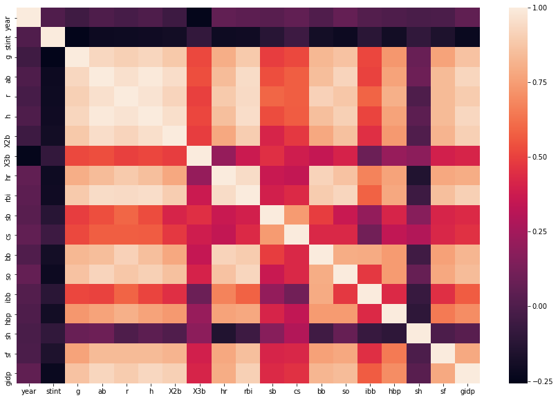

```python
import seaborn as sns
corr = baseball.corr()
fig, ax = plt.subplots(figsize=(15,10))
sns.heatmap(corr,
            xticklabels=corr.columns.values,
            yticklabels=corr.columns.values,
            ax=ax)
```

## Writing Data to Files

As well as being able to read several data input formats, Pandas can also export data to a variety of storage formats. We will bring your attention to just a couple of these.

```python
mb.to_csv("mb.csv")
```

The `to_csv` method writes a `DataFrame` to a comma-separated values (csv) file. You can specify custom delimiters (via `sep` argument), how missing values are written (via `na_rep` argument), whether the index is writen (via `index` argument), whether the header is included (via `header` argument), among other options.